# ProActive

## Output

The output of `ProActiveDetect()` is a list containing six objects:

1. SummaryTable: A table containing all pattern-matching classifications
2. CleanSummaryTable: A table containing only Gap and Elevation pattern-match classifications (i.e. noPattern classifications removed)
3. PatternMatches: A list object containing information needed to visualize the pattern-matches in `plotProActiveResults()`
4. FilteredOut: A table containing contigs/chunks that were filtered out for being too small or having too low read coverage
5. Arguments: A list object containing arguments used for pattern-matching (windowSize, mode, chunkSize, chunkContigs)
6. GeneAnnotTable: A table containing gene annotations associated with elevated or gapped regions in pattern-matches

Save the desired list item to a new variable using its associated name.

**Metagenome results summary table:**

```r
MetagenomeCleanSummaryTable <- ProActiveOutputMetagenome$CleanSummaryTable
```

| refName | classification | elevRatio | startPos | endPos | matchSize |
| --- | --- | --- | --- | --- | --- |
| NODE_1911 | Elevation | 3.349296 | 1000 | 17000 | 16000 |
| NODE_1583 | Elevation | 2.450013 | 42000 | 51000 | 9000 |
| NODE_1884 | Gap | 3.319514 | 36000 | 44000 | 8000 |
| NODE_1255 | Gap | 5.318072 | 1000 | 20000 | 19000 |
| NODE_368 | Gap | 2.690172 | 26000 | 56000 | 30000 |
| NODE_617 | Elevation | 1.784556 | 34000 | 82000 | 48000 |

**Subset of genome results summary table:**

```r
GenomeCleanSummaryTable <- head(ProActiveOutputGenome$CleanSummaryTable)
```

|  | refName | classification | elevRatio | startPos | endPos | matchSize |
| --- | --- | --- | --- | --- | --- | --- |
| 3 | NC_003197.2_chunk_3 | Gap | 1.609512 | 283000 | 300000 | 17000 |
| 4 | NC_003197.2_chunk_4 | Elevation | 1.351684 | 339000 | 351000 | 12000 |
| 7 | NC_003197.2_chunk_7 | Elevation | 1.343521 | 692000 | 700000 | 8000 |
| 8 | NC_003197.2_chunk_8 | Elevation | 1.723227 | 784000 | 794000 | 10000 |
| 10 | NC_003197.2_chunk_10 | Elevation | 1.887571 | 964000 | 1000000 | 36000 |
| 12 | NC_003197.2_chunk_12 | Elevation | 1.293144 | 1134000 | 1144000 | 10000 |

**Subset of GeneAnnotTable for metagenome results:**

```r
MetagenomeResultsGenePredictTable <- head(ProActiveOutputMetagenome$GeneAnnotTable)
```

seqid

source

type

start

end

score

strand

phase

attributes

geneproduct

Classification

NODE_1911

Prodigal:002006

CDS

318

1166

.

0

ID=NJKKNKEE_164175;inference=ab initio prediction:Prodigal:002006;locus_tag=NJKKNKEE_164175;product=hypothetical protein

hypothetical protein

Elevation

NODE_1911

Prodigal:002006

CDS

1198

1938

.

0

ID=NJKKNKEE_164176;inference=ab initio prediction:Prodigal:002006;locus_tag=NJKKNKEE_164176;product=hypothetical protein

hypothetical protein

Elevation

NODE_1911

Prodigal:002006

CDS

1938

2582

.

0

ID=NJKKNKEE_164177;inference=ab initio prediction:Prodigal:002006;locus_tag=NJKKNKEE_164177;product=hypothetical protein

hypothetical protein

Elevation

NODE_1911

Prodigal:002006

CDS

2722

3561

.

0

ID=NJKKNKEE_164178;inference=ab initio prediction:Prodigal:002006;locus_tag=NJKKNKEE_164178;product=hypothetical protein

hypothetical protein

Elevation

NODE_1911

Prodigal:002006

CDS

3671

4063

.

0

ID=NJKKNKEE_164179;inference=ab initio prediction:Prodigal:002006;locus_tag=NJKKNKEE_164179;product=hypothetical protein

hypothetical protein

Elevation

NODE_1911

Prodigal:002006

CDS

4128

4670

.

0

ID=NJKKNKEE_164180;eC_number=1.11.1.1;Name=rbr1_24;db_xref=COG:COG1592;gene=rbr1_24;inference=ab initio prediction:Prodigal:002006,similar to AA sequence:UniProtKB:Q97FZ9;locus_tag=NJKKNKEE_164180;product=Rubrerythrin-1

Rubrerythrin-1

Elevation

**Subset of GeneAnnotTable for genome results:**

```r
GenomeResultsGenePredictTable <- head(ProActiveOutputGenome$GeneAnnotTable)
```

seqid

source

type

start

end

score

strand

phase

attributes

geneproduct

Classification

NC_003197.2_chunk_3

Prodigal:002006

CDS

282468

284186

.

0

ID=LFLNNMPD_00240;eC_number=6.1.1.15;Name=proS;db_xref=COG:COG0442;gene=proS;inference=ab initio prediction:Prodigal:002006,similar to AA sequence:UniProtKB:P16659;locus_tag=LFLNNMPD_00240;product=Proline–tRNA ligase

Proline–tRNA ligase

Gap

NC_003197.2_chunk_3

Prodigal:002006

CDS

284297

285004

.

0

ID=LFLNNMPD_00241;eC_number=2.1.1.-;Name=trmO;db_xref=COG:COG1720;gene=trmO;inference=ab initio prediction:Prodigal:002006,similar to AA sequence:UniProtKB:P28634;locus_tag=LFLNNMPD_00241;product=tRNA (adenine(37)-N6)-methyltransferase

tRNA (adenine(37)-N6)-methyltransferase

Gap

NC_003197.2_chunk_3

Prodigal:002006

CDS

285001

285405

.

0

ID=LFLNNMPD_00242;Name=rcsF;gene=rcsF;inference=ab initio prediction:Prodigal:002006,similar to AA sequence:UniProtKB:P69411;locus_tag=LFLNNMPD_00242;product=Outer membrane lipoprotein RcsF

Outer membrane lipoprotein RcsF

Gap

NC_003197.2_chunk_3

Prodigal:002006

CDS

285524

286339

.

0

ID=LFLNNMPD_00243;Name=metQ_1;db_xref=COG:COG1464;gene=metQ_1;inference=ab initio prediction:Prodigal:002006,similar to AA sequence:UniProtKB:P28635;locus_tag=LFLNNMPD_00243;product=D-methionine-binding lipoprotein MetQ

D-methionine-binding lipoprotein MetQ

Gap

NC_003197.2_chunk_3

Prodigal:002006

CDS

286378

287031

.

0

ID=LFLNNMPD_00244;Name=metI;db_xref=COG:COG2011;gene=metI;inference=ab initio prediction:Prodigal:002006,similar to AA sequence:UniProtKB:P31547;locus_tag=LFLNNMPD_00244;product=D-methionine transport system permease protein MetI

D-methionine transport system permease protein MetI

Gap

NC_003197.2_chunk_3

Prodigal:002006

CDS

287024

288055

.

0

ID=LFLNNMPD_00245;eC_number=3.6.3.-;Name=metN_1;db_xref=COG:COG1135;gene=metN_1;inference=ab initio prediction:Prodigal:002006,similar to AA sequence:UniProtKB:P30750;locus_tag=LFLNNMPD_00245;product=Methionine import ATP-binding protein MetN

Methionine import ATP-binding protein MetN

Gap

# plotProActiveResults()

`plotProActiveResults()` allows users to visualize both the read coverage and the pattern-match associated with each Gap or Elevation classification.

## Function components

### Re-building pattern-matches

The `ProActiveDetect()` output contains information needed to re-build each pattern-match used for classification. To re-build a complete pattern-match for visualization, `plotProActiveResults()` uses the pattern-match’s minimum and maximum values and the start and stop positions.

### Plotting read coverage and associated pattern-matches

By default, the read coverage is plotted for each contig/chunk classified as having a Gap or Elevation in read coverage. If you wish to see the read coverage for noPattern classifications, be sure to set `IncludeNoPatterns = TRUE` when running `ProActiveDetect()`. The pattern-match associated with each classification is overlaid on the coverage plot.

## Usage

**Default arguments:**

```r
MetagenomeResultsPlots <- plotProActiveResults(
  pileup = sampleMetagenomePileup,
  ProActiveResults = ProActiveOutputMetagenome
)

GenomeResultsPlots <- plotProActiveResults(
  pileup = sampleGenomePileup,
  ProActiveResults = ProActiveOutputGenome
)
```

**Note**- There is no need to set ‘genome’ or ‘metagenome’ mode. `plotProActiveResults()` will get this information from the `ProActiveDetect()` output.

## Arguments/parameters

```r
plotProActiveResults(pileup,
  ProActiveResults,
  elevFilter,
  saveFilesTo
)
```

- **`pileup`**: A .txt file containing mapped sequencing read coverages averaged over 100 bp windows/bins.
- **`ProActiveResults`**: The output from `ProActiveDetect()`.
- **`elevFilter`**: Optional, only plot results with pattern-matches that achieved an elevation ratio (max/min) greater than the specified value. Default is no filter.
- **`saveFilesTo`**: Optional, Provide a path to the directory you wish to save output to. A folder will be made within the provided directory to store results.

## Output

The output of `plotProActiveResults()` is a list of ggplot objects.

### View select metagenome plots

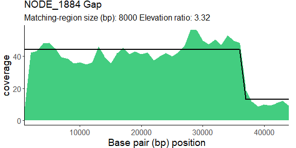

```r
MetagenomeResultsPlots$NODE_1884
```

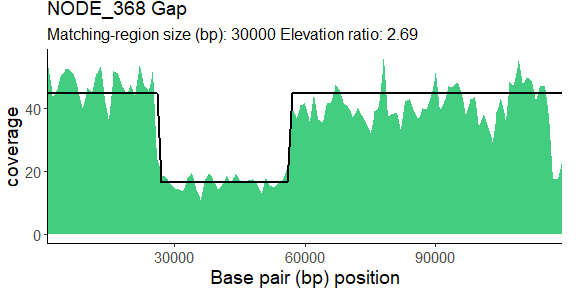

```r
MetagenomeResultsPlots$NODE_368
```

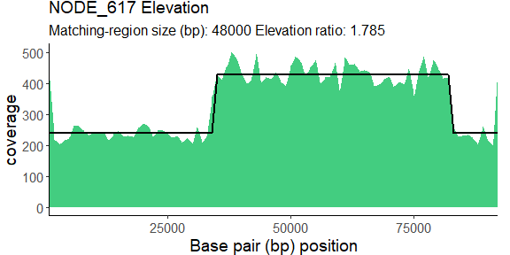

```r
MetagenomeResultsPlots$NODE_617
```

### View select genome plots

**Notice the ‘chunk’ information in the plot titles**

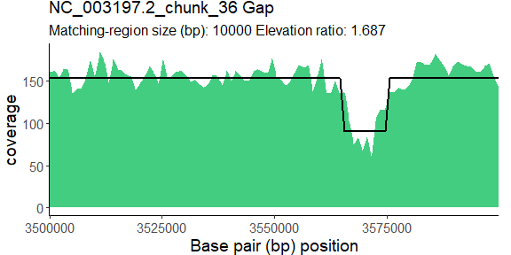

```r
GenomeResultsPlots$NC_003197.2_chunk_36
```

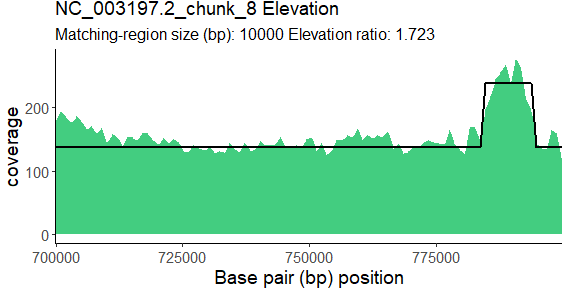

```r
GenomeResultsPlots$NC_003197.2_chunk_8
```

# geneAnnotationSearch()

`geneAnnotationSearch()` helps users explore gene annotations of interest in and around detected gaps and elevations in read coverage.

## Function components

### Search for gene annotations

`geneAnnotationSearch()` utilizes a .gff file and the pattern-matching results from `ProActiveDetect()` to locate gene annotations that match provided `keyWords`. The .gff file should be in the same format described previously in the Input Files section of this vignette. First, the information associated with the gene or gene product (depending on what the user selects for the `geneOrProduct` parameter) is extracted from the attributes column of the .gff file. Then, the .gff file is subset to include only the annotations associated with the contig/chunk being assessed. From here, the search can vary quite a bit depending on the parameters the user selects for the `inGapOrElev` and `bpRange` parameters. If `inGapOrElev = FALSE` (the default), then gene annotations located anywhere on the contig/chunk that match one or more of the provided `keyWords` will be visualized. If `inGapOrElev = TRUE`, then only gene annotations within the gap/elevation region of the pattern-match will be searched for matches to the provided `keyWords`. The `bpRange` parameter can be used if `inGapOrElev = TRUE` and allows the search range to be extended a specified number of base pairs to the left and right of the gap/elevation pattern-match borders. Gene annotation are included in the search if the end of the open reading frame (defined by the ‘end’ values in the .gff file) falls within the search region.

### Plot gene annotation locations

The read coverage and locations of gene annotations that match the provided `keyWords` are visualized for each contig/chunk with matches. The read coverage is plotted using a 100 bp windowSize to allow for greater resolution of read coverage patterns and gene annotation locations. The borders of the elevated/gapped regions of read coverage detected by `ProActiveDetect()` are marked on the plot with orange vertical lines. If `inElevOrGap = TRUE` and `bpRange` is set to a non-zero value, then the extended search range outside the gap/elevation borders are marked on the plot with orange dashed vertical lines. The matching gene annotation locations are marked on the plot with black vertical lines at the start position of the associated open reading frames.

**Note**- The pattern-matching used to identify the borders of elevated and gapped regions of read coverage was *likely* performed using a `windowSize` larger than 100 bp in `ProActiveDetect()`. This means that the locations of the borders may not perfectly translate to the borders of gaps and elevations at 100 bp resolution.

## Usage

**Default arguments:**

With defaults, all contigs/chunks classified as having a gap or elevation in read coverage are searched for gene annotations that match any of the provided keywords. The entire contig/chunk is searched, not just the gapped or elevated region.

```r
MetagenomeGeneMatches <- geneAnnotationSearch(
  ProActiveResults = ProActiveOutputMetagenome,
  pileup = sampleMetagenomePileup,
  gffTSV = sampleMetagenomegffTSV,
  geneOrProduct = "product",
  keyWords = c("transport", "chemotaxis")
  )
```

```
#> Cleaning gff file...
#> Cleaning pileup file...
#> Searching for matching annotations...
#> 3 contigs/chunks have gene annotations that match one or more of the provided keyWords
```

**Non-default arguments**

With the following parameters/arguments, all classified contigs/chunks are searched for gene annotations that match the provided keywords (same as default), BUT with the use of `inGapOrElev = TRUE`, only the gapped or elevated region is searched for matching annotations. Additionally, the use of `bpRange = 5000` means that the search region is extended 5,000 bp from the left and right of the gapped or elevated region.

```r
GenomeGeneMatches <- geneAnnotationSearch(
  ProActiveResults = ProActiveOutputGenome,
  pileup =  sampleGenomePileup,
  gffTSV = sampleGenomegffTSV,
  geneOrProduct = "product",
  keyWords = c("ribosomal"),
  inGapOrElev = TRUE,
  bpRange = 5000
  )
```

```
#> Cleaning gff file...
#> Cleaning pileup file...
#> Searching for matching annotations...
#> 8 contigs/chunks have gene annotations that match one or more of the provided keyWords
```

## Arguments/parameters

```r
geneAnnotationSearch(
  ProActiveResults,
  pileup,
  gffTSV,
  geneOrProduct,
  keyWords,
  inGapOrElev = FALSE,
  bpRange = 0,
  elevFilter,
  saveFilesTo,
  verbose = TRUE
  )
```

- **`ProActiveResults`**: The output from `ProActiveDetect()`.
- **`pileup`**: A .txt file containing mapped sequencing read coverages averaged over 100 bp windows/bins.
- **`gffTSV`**: A .gff file (TSV) containing gene annotations associated with the .fasta file used to generate the pileup.
- **`geneOrProduct`**: “gene” or “product”. Search for keyWords associated with genes or gene products.
- **`keyWords`**: The keyWord(s) to search for. Case independent. Searches will return the string #’ that contains the matching keyWord. KeyWord(s) must be in quotes, comma-separated, and surrounded by #’ c() i.e( c(“antibiotic”, “resistance”, “drug”) )
- **`inGapOrElev`**: TRUE or FALSE. If TRUE, only search for gene-annotations in #’ the gap/elevation region of the pattern-match. Default is FALSE (i.e search the #’ entire contig/chunk for the gene annotation key-words)
- **`bpRange`**: If `inGapOrElev = TRUE`, the user may specify the region (in base pairs) that should #’ be searched to the left and right of the gap/elevation region. Default is 0.
- **`elevFilter`**: Optional, only plot results with pattern-matches that achieved an elevation ratio (max/min) greater than the specified value. Default is no filter.
- **`saveFilesTo`**: Optional, Provide a path to the directory you wish to save output to. A folder will be made within the provided directory to store results.
- **`verbose`**: TRUE or FALSE. Print progress messages to console. Default is TRUE.

## Output

The output of `geneAnnotationSearch()` is a list of ggplot objects.

Default search parameters:

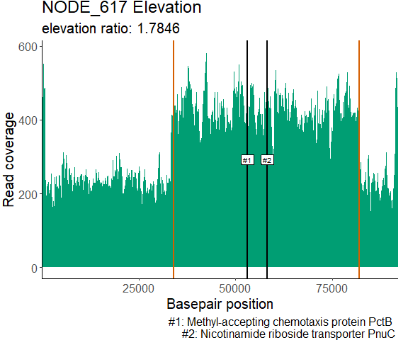

```r
MetagenomeGeneMatches$NODE_617
```

Non-default search parameters (use of `inGapOrElev` = TRUE and `bpRange` = 5000)

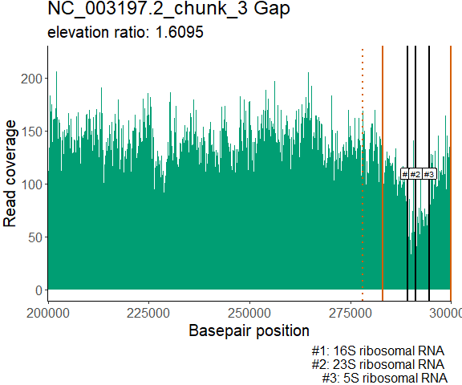

```r
GenomeGeneMatches$NC_003197.2_chunk_3
```

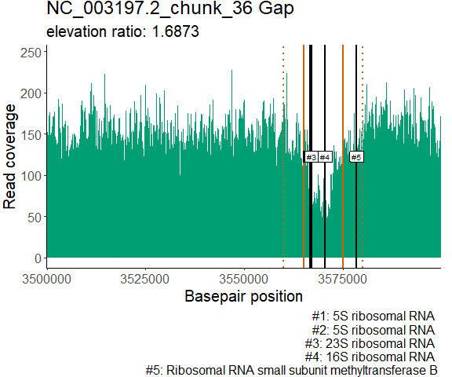

```r
GenomeGeneMatches$NC_003197.2_chunk_36
```